# Sensibilisation à l’IA (générative)

Abiré Poko

Émilien Schultz

## Pourquoi cet échange ?

- Discussion de nos pratiques actuelles
- Point sur les évolutions en cours
- Situer les évolutions à l’ENSAE/professionnelles
- Réfléchir aux bonnes pratiques

# De nouvelles pratiques

## Diffusion de l’IA (générative)

Ne pas se retrouver piégé par les promesses béates ou les discours de fin du monde – être humble

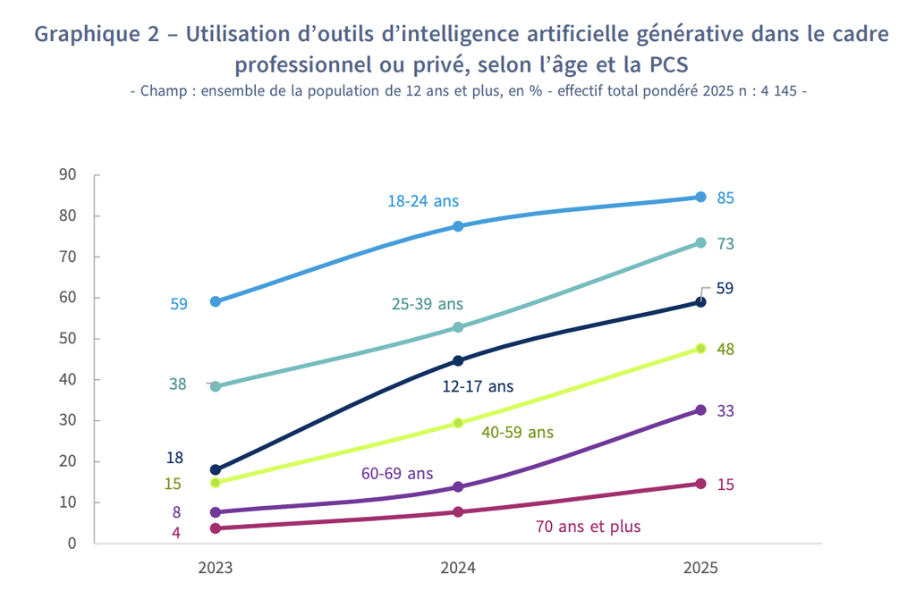

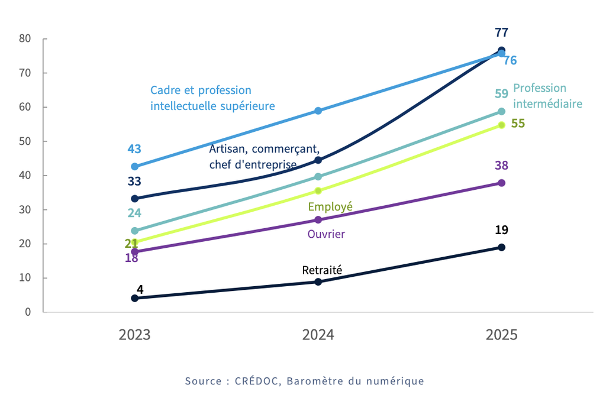

## Carte de nos pratiques actuelles

Construisons ensemble une carte détaillée de nos pratiques

- gauche/droite : - spécialisé à + spécialisé
- bas/haut : innovant - à innovant +

[Tableau Excalidraw](https://excalidraw.com/#room=4af6fcdf614689b8fb9a,flGWtUi8C_YJbFcxUWAroA)

[figure not shown]

## Nos pratiques au concret

**Abiré** → Activité de statisticienne / data scientist

- Revue de littérature
- Traitement de données
- Migration de code d’un outil vers un autre
- Automatisation de reporting

## Nos pratiques au concret

**Émilien** → Activité de développement et de recherche

- De nouvelles méthodes de traitement des données utilisant des modèles (image, texte, …)
- Moins de temps à programmer, plus à concevoir
- Accélération de production des démonstrateurs
- Plus de temps passé sur la veille et à tester de nouveaux outils

# De nouveaux outils – de nouveaux concepts

## Dépasser l’hégémonie d’un mot

« Intelligence artificielle » recouvre :

- Des technologies sous-jacentes plurielles et évolutives (qui ne se limitent pas au génératif)
- Des services (logiciels) construits dessus

**Dépasser le statut d’utilisateur de services pour se poser la question de leur fonctionnement**

## De nouveaux concepts

**A**gent  
**B**enchmark  
**C**hatbot  
**D**iffusion (modèle de)  
**E**mbeddings  
**F**ine-tuning  
**G**énératif  
**H**allucination  
**I**nférence  
**J**ailbreak  
**K**nowledge distillation  
**L**LM  
**M**ultimodal

**N**eurones (réseau de)  
**O**pen source/weight  
**P**rompt  
**Q**uantization  
**R**LHF  
**S**ynthétiques (données)  
**T**oken  
**U**nsupervised (learning)  
**V**alidation  
**W**atermarking  
**X**AI  
**Y**ann LeCun  
**Z**ero-shot

# Évolution des trajectoires professionnelles

## Demande des entreprises

- Retour d’expérience
- Table ronde entre Sopra Steria en partenariat avec AGIRES

## Demande des entreprises

- L’industrie ne veut pas de magiciens IA
- Fin de l’ingénieur « pur producteur de code »
- Plus de compétences de base attendues par les entreprises : pensée critique, rigueur

## Demande des entreprises

- Forte demande pour des profils hybrides : IA + données, IA + cybersécurité
- Une compétence recherchée en plus : le côté humain

# L’IA dans les parcours à l’ENSAE

## Retour sur la charte IA

- Fil rouge de la charte : usage assisté vs usage délégué
- Principe de base : l’IA ne remplace pas l’apprentissage
- Dans les évaluations, l’IA n’est autorisée que si l’enseignant le précise

## Retour sur la charte IA

- Transparence obligatoire
- Chacun reste responsable de ce qu’il rend, y compris en groupe
- Données et sobriété : des règles concrètes, pas juste des principes

## Retour sur la charte IA

- Ce qui change concrètement dans le parcours
- En stage / alternance
- En cas de manquement ?

# Nouveaux risques & bonnes pratiques

## Évolution permanente des dispositifs

Les outils/modèles ne cessent d’évoluer ce qui rend le paysage complexe

→ importance de garder une attitude de veille et d’expérimentation ; ne pas devenir dépendant d’un service

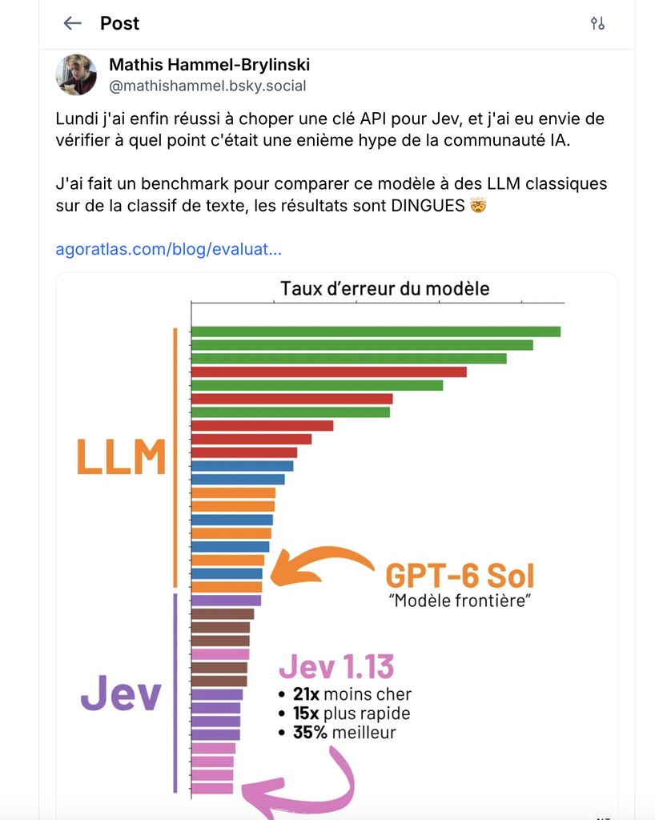

## Fuite de données et confidentialité

Un des risques, c’est ce qu’on envoie à l’IA : cas de Samsung en 2023

→ Décrivez la forme de vos données, pas les données ; utiliser des solutions locales

→ En stage, suivez les règles de l’entreprise

[figure not shown]

## Risques sur l’apprentissage

Multiplication des moments de **démission cognitive** (*cognitive surrender*) surtout sous pression

→ identifier explicitement les moments d’apprentissage qui ne peuvent pas être remplacés & trouver de nouvelles manières d’intégrer ces outils

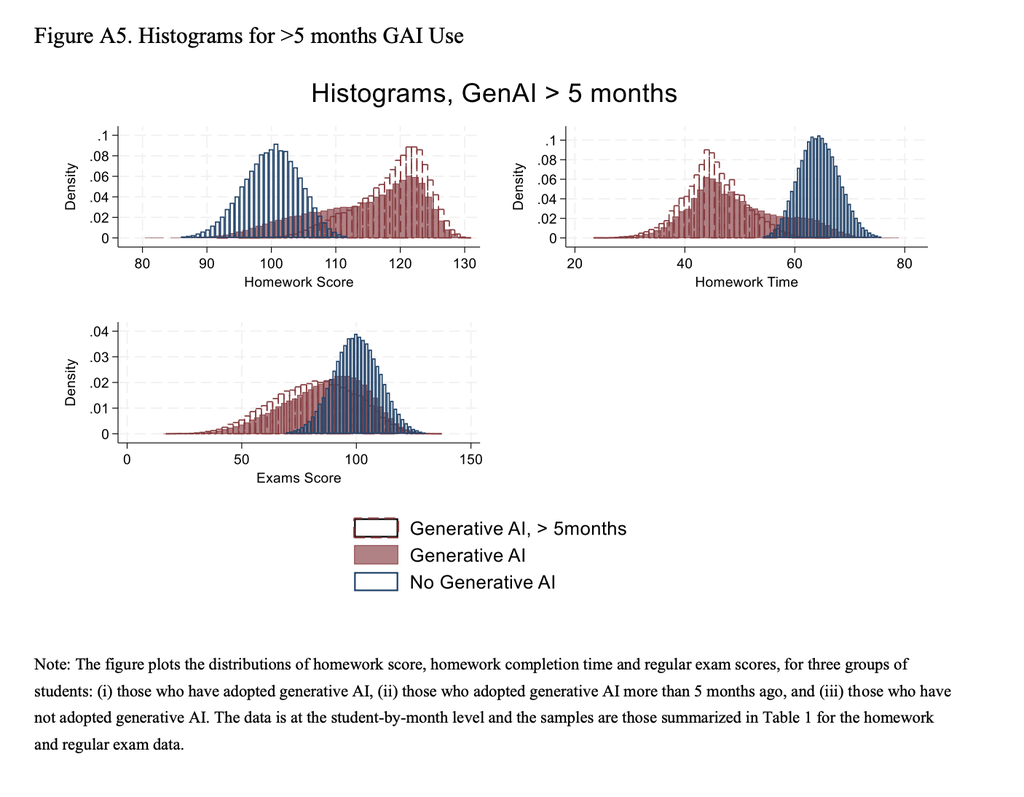

[Article](https://papers.ssrn.com/sol3/papers.cfm?abstract_id=6868618)

## Impact environnemental

Explosion de la consommation énergétique

→ Ouvrir la boite noire des systèmes qu’on utilise, leur chaîne de production et leurs conséquences – aller vers des modèles **frugaux**

[figure not shown]

## Risques sur le prix de l’IA

De nouveaux coûts pour vous & les entreprises et des modèles économiques encore incertains

→ Réfléchir la place des modèles dans les usages / de nouveaux postes dans les entreprises

[figure not shown]

## Risque de remplacement

Promesse de l’automatisation de nombreuses tâches et disparition de certaines fonctions

→ Garder l’humain dans la boucle car la vérification et la compréhension restent nécessaires sur le long terme – un enjeu d’ingénierie de données

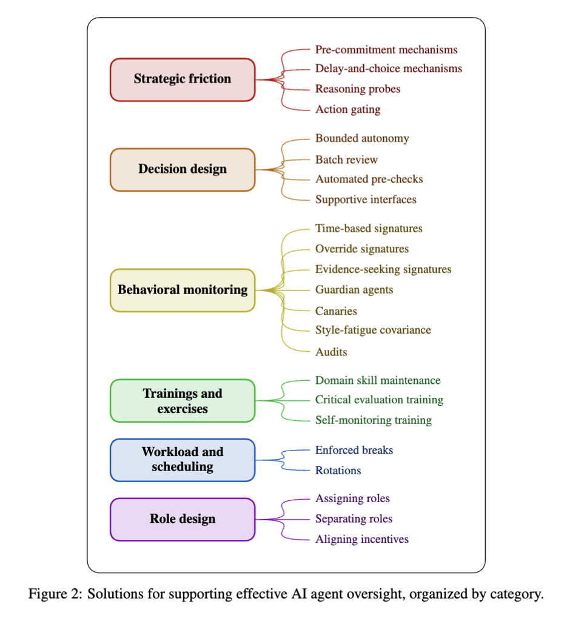

[Article](https://arxiv.org/abs/2608.23642)

# Continuons ce dialogue

## Les prochaines étapes

- La réflexion sur les transformations en cours est un processus et pas un point d’arrivée, dont vous faites partie
- Organisation des petits groupes de tables rondes avec des professeurs **à venir**
- Pour toute information sur les enjeux IA & scolarité : apoko@ensae.fr

## Ressources

- [Rapport MIT AI and Education](https://aiandeducation.mit.edu/report/)
- [LLM de l’INSEE (Onyxia)](https://llm.lab.sspcloud.fr/)